```python
import numpy as np
import random
from scipy import optimize
import time
```

# Exercice 1

## 1) We will assert if our objective function and the two other inequality constraint functions are convex

```python
def f_0(x,y):
    return np.exp(x)*(4*x*x+2*y*y+4*x*y+2*y+1)
def f_1(x,y):
    return x*y-x-y+1.5
def f_2(x,y):
    return -x*y-10
```

```python
x1=float()
x2=float()
y1=float()
y2=float()
sum=0
for i in range (10):
    a = random.random()
    if f_0(a*x1+(1-a)*x2,a*y1+(1-a)*y2)> a*f_0(x1,y1)+(1-a)*f_0(x2,y2):
        sum+=1
## sum gives us the number of times the inequality is not respected out of the 10 maximum possible times
print(sum)
```

```
0
```

The objective function f_0 is thus a convex function

```python
x1=float()
x2=float()
y1=float()
y2=float()
sum=0
for i in range (10):
    a = random.random()
    if f_1(a*x1+(1-a)*x2,a*y1+(1-a)*y2)> a*f_1(x1,y1)+(1-a)*f_1(x2,y2):
        sum+=1
## sum gives us the number of times the inequality is not respected out of the 10 maximum possible times
print(sum)
```

```
0
```

```python
x1=float()
x2=float()
y1=float()
y2=float()
sum=0
for i in range (10):
    a = random.random()
    if f_2(a*x1+(1-a)*x2,a*y1+(1-a)*y2)> a*f_2(x1,y1)+(1-a)*f_2(x2,y2):
        sum+=1
## sum gives us the number of times the inequality is not respected out of the 10 maximum possible times
print(sum)
```

```
0
```

Thi problem is a convex optimization problem

## 2)

```python
def f_0(x):
    return np.exp(x[0])*(4*x[0]*x[0]+2*x[1]*x[1]+4*x[0]*x[1]+2*x[1]+1)
x0= [0,0]
optimize.minimize (f_0,x0)
```

```
      fun: 2.9971761830880393e-12
 hess_inv: array([[ 0.15176223, -0.149116  ],
       [-0.149116  ,  0.35912721]])
      jac: array([6.58419020e-06, 6.28937276e-06])
  message: 'Optimization terminated successfully.'
     nfev: 33
      nit: 8
     njev: 11
   status: 0
  success: True
        x: array([ 0.50000004, -0.99999908])
```

It took the algorithm 8 iterations in order to find the optimal value, but it doesn't respect the condition of f_1 so we won't consider it

```python
def f_0(x):
    return np.exp(x[0])*(4*x[0]*x[0]+2*x[1]*x[1]+4*x[0]*x[1]+2*x[1]+1)
def f_1(x):
    return -x[0]*x[1]+x[0]+x[1]-1.5
def f_2(x):
    return x[0]*x[1]+10
cons = ({'type': 'ineq','fun' : f_1},{'type': 'ineq','fun' : f_2})
x0= [0,0]
optimize.minimize (f_0,x0,constraints= cons)
```

```
     fun: 0.023550379624174854
     jac: array([ 0.01839703, -0.00228436])
 message: 'Optimization terminated successfully'
    nfev: 54
     nit: 17
    njev: 17
  status: 0
 success: True
       x: array([-9.54740503,  1.04740503])
```

It took the algorithm 17 iterations in order to find the optimal value

```python
def f_0(x):
    return np.exp(x[0])*(4*x[0]*x[0]+2*x[1]*x[1]+4*x[0]*x[1]+2*x[1]+1)
def f_1(x):
    return -x[0]*x[1]+x[0]+x[1]-1.5
def f_2(x):
    return x[0]*x[1]+10
cons = ({'type': 'ineq','fun' : f_1},{'type': 'ineq','fun' : f_2})
x0= [10,20]
optimize.minimize (f_0,x0,constraints= cons)
```

```
     fun: 44956016.68720051
     jac: array([48480251.5,  2687229. ])
 message: 'Inequality constraints incompatible'
    nfev: 3
     nit: 1
    njev: 1
  status: 4
 success: False
       x: array([10., 20.])
```

It took the algorithm 1 iteration in order to find the optimal value, bit this value doesn't verify the conditions

```python
def f_0(x):
    return np.exp(x[0])*(4*x[0]*x[0]+2*x[1]*x[1]+4*x[0]*x[1]+2*x[1]+1)
def f_1(x):
    return -x[0]*x[1]+x[0]+x[1]-1.5
def f_2(x):
    return x[0]*x[1]+10
cons = ({'type': 'ineq','fun' : f_1},{'type': 'ineq','fun' : f_2})
x0= [-10,1]
optimize.minimize (f_0,x0,constraints= cons)
```

```
     fun: 0.0235503796241749
     jac: array([ 0.01839703, -0.00228436])
 message: 'Optimization terminated successfully'
    nfev: 10
     nit: 3
    njev: 3
  status: 0
 success: True
       x: array([-9.54740503,  1.04740503])
```

It took about 3 iterations for the algorithm in order to find the optimal value, the value is not respecting the condition relative to the function f_1 so we won't consider it

```python
def f_0(x):
    return np.exp(x[0])*(4*x[0]*x[0]+2*x[1]*x[1]+4*x[0]*x[1]+2*x[1]+1)
def f_1(x):
    return x[0]*x[1]-x[0]-x[1]+1.5
def f_2(x):
    return -x[0]*x[1]-10
cons = ({'type': 'ineq','fun' : f_1},{'type': 'ineq','fun' : f_2})
x0= [-30,30]
optimize.minimize (f_0,x0,constraints= cons)
```

```
     fun: 5.384095757961196e-05
     jac: array([ 4.72560305e-05, -3.08820336e-06])
 message: 'Optimization terminated successfully'
    nfev: 16
     nit: 5
    njev: 5
  status: 0
 success: True
       x: array([-16.80028037,   1.02808945])
```

The constraints are not always satisfied in the values found for some initial conditions. These values don't respond to our problem and won't thus be considered

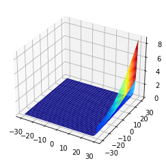

```python
# surface plot for 2d objective function
from numpy import arange
from numpy import meshgrid
from matplotlib import pyplot
from mpl_toolkits.mplot3d import Axes3D

# objective function
def objective(x,y):
	return np.exp(x)*(4*x*x+2*y*y+4*x*y+2*y+1)

# define range for input
r_min, r_max = -30.0, 30.0
# sample input range uniformly at 0.1 increments
xaxis = arange(r_min, r_max, 0.1)
yaxis = arange(r_min, r_max, 0.1)
# create a mesh from the axis
x, y = meshgrid(xaxis, yaxis)
# compute targets
results = objective(x,y)
# create a surface plot with the jet color scheme
figure = pyplot.figure()
axis = figure.gca(projection='3d')
axis.plot_surface(x, y, results, cmap='jet')
# show the plot
pyplot.show()
```

We see that the function increases drastically with x as the exponential term was suggesting. We can assert that the regions y<0 and (x<0,y<10) are where the minimum is realised

```python
def jacob_f(x):
    dx=(4*x[0]*x[0]+2*x[1]*x[1]+4*x[0]*x[1]+2*x[1]+1+8*x[0]+4*x[1])*np.exp(x[0])
    dy=np.exp(x[0])*(4*x[1]+4*x[0]+2)
    return np.array((dx, dy))
```

```python
x0=[0,0]
optimize.minimize(f_0, x0, constraints=cons,jac=jacob_f)
```

```
     fun: 366.53955023361425
     jac: array([281.57265955, -91.2078468 ])
 message: 'Optimization terminated successfully'
    nfev: 50
     nit: 24
    njev: 23
  status: 0
 success: True
       x: array([ 1.04740503, -9.54740503])
```

```python
x0=[-30,30]
optimize.minimize(f_0, x0, constraints=cons,jac=jacob_f)
```

```
     fun: 5.384095729903796e-05
     jac: array([ 4.72560290e-05, -3.08820305e-06])
 message: 'Optimization terminated successfully'
    nfev: 6
     nit: 5
    njev: 5
  status: 0
 success: True
       x: array([-16.80028038,   1.02808945])
```

```python
x0=[-10,1]
optimize.minimize(f_0, x0, constraints=cons,jac=jacob_f)
```

```
     fun: 7.722463414496068e-07
     jac: array([ 1.40196390e-06, -7.27033041e-08])
 message: 'Optimization terminated successfully'
    nfev: 18
     nit: 17
    njev: 17
  status: 0
 success: True
       x: array([-21.56501029,   0.83879243])
```

```python
x0=[10,20]
optimize.minimize(f_0, x0, constraints=cons,jac=jacob_f)
```

```
     fun: 0.02352722112017674
     jac: array([ 0.01837945, -0.00228182])
 message: 'Optimization terminated successfully'
    nfev: 22
     nit: 9
    njev: 9
  status: 0
 success: True
       x: array([-9.54866514,  1.04739936])
```

# Exercise 2

## 1)

```python
def f(x):
    return x[0]**2 + x[1]**2
```

```python
def f_1(x):
    return x[0]-0.5
def f_2(x):
    return x[0]+x[1]-1
def f_3(x):
    return -f(x)-1
def f_4(x):
    return 8*x[0]**2+f(x)-9
def f_5(x):
    return x[0]**2-x[1]
def f_6(x):
    return x[1]**2-x[0]
```

```python
def f_7(x,y):
    return x**2 + y**2
x1=float()
x2=float()
y1=float()
y2=float()
sum=0
for i in range (10):
    a = random.random()
    if f_7(a*x1+(1-a)*x2,a*y1+(1-a)*y2)> a*f_7(x1,y1)+(1-a)*f_7(x2,y2):
        sum+=1
## sum gives us the number of times the inequality of convexity is not respected out of the 10 maximum possible times
print(sum)
```

```
0
```

f is thus a convex function

The function f_3 is not a convex function beacause -f is concave, the probleme is thus quasi convex

## 2)

```python
cons = ({'type': 'ineq','fun' : f_1},{'type': 'ineq','fun' : f_2},{'type': 'ineq','fun' : f_3},{'type': 'ineq','fun' : f_4},{'type': 'ineq','fun' : f_5},{'type': 'ineq','fun' : f_6})
x0= [1,1]
optimize.minimize (f,x0,constraints= cons)
```

```
     fun: 2.0
     jac: array([2., 2.])
 message: 'Positive directional derivative for linesearch'
    nfev: 3
     nit: 5
    njev: 1
  status: 8
 success: False
       x: array([1., 1.])
```

```python
cons = ({'type': 'ineq','fun' : f_1},{'type': 'ineq','fun' : f_2},{'type': 'ineq','fun' : f_3},{'type': 'ineq','fun' : f_4},{'type': 'ineq','fun' : f_5},{'type': 'ineq','fun' : f_6})
x0= [0,0]
optimize.minimize (f,x0,constraints= cons)
```

```
     fun: 6.581785094464021e-29
     jac: array([1.49011450e-08, 1.49011613e-08])
 message: 'Positive directional derivative for linesearch'
    nfev: 68
     nit: 10
    njev: 6
  status: 8
 success: False
       x: array([-8.11275519e-15,  3.24673420e-17])
```

This solution doesn't work the conditions are not respected.

```python
def f(x):
    return x[0]**2 + x[1]**2
def jacob_f(x):
    dx=2*x[0]
    dy=2*x[1]
    return np.array((dx,dy))
```

```python
x0=[1,1]
optimize.minimize(f, x0, constraints=cons,jac=jacob_f)
```

```
     fun: 2.0
     jac: array([2., 2.])
 message: 'Positive directional derivative for linesearch'
    nfev: 1
     nit: 5
    njev: 1
  status: 8
 success: False
       x: array([1., 1.])
```

# Exercice 3

## 1) Checking whether it's a COP problem

```python
def f(x,y):
    return x**2+y**2
def f_1(x,y):
    return f(x,y)+x*y-3
def f_2(x,y):
    return -1*(3*x+2*y-3)
```

```python
x1=float()
x2=float()
y1=float()
y2=float()
sum=0
for i in range (10):
    a = random.random()
    if f(a*x1+(1-a)*x2,a*y1+(1-a)*y2)> a*f(x1,y1)+(1-a)*f(x2,y2):
        sum+=1
## sum gives us the number of times the inequality is not respected out of the 10 maximum possible times
print(sum)
```

```
0
```

f is thus a convex function

```python
x1=float()
x2=float()
y1=float()
y2=float()
sum=0
for i in range (10):
    a = random.random()
    if f_1(a*x1+(1-a)*x2,a*y1+(1-a)*y2)> a*f_1(x1,y1)+(1-a)*f_1(x2,y2):
        sum+=1
## sum gives us the number of times the inequality is not respected out of the 10 maximum possible times
print(sum)
```

```
0
```

f_1 is a convex function

```python
x1=float()
x2=float()
y1=float()
y2=float()
sum=0
for i in range (10):
    a = random.random()
    if f_2(a*x1+(1-a)*x2,a*y1+(1-a)*y2)> a*f_2(x1,y1)+(1-a)*f_2(x2,y2):
        sum+=1
## sum gives us the number of times the inequality is not respected out of the 10 maximum possible times
print(sum)
```

```
0
```

f_2 is a convex functionThe Problem is thus a convex optimization problem

## 2) Solving using scipy

```python
# Jacobian
def fun_Jac(x):
    dx = 2*x[0]
    dy = 2*x[1]
    return np.array((dx, dy))

# Jacobian
def fun_Hess(x):
    d11 = 2.
    d12 = 0.
    d22 = 2.
    return np.array(((d11, d12),(d12, d22)))
```

```python
# Objective function
fun = lambda x: x[0]**2 + x[1]**2
```

```python
# constraints functions
cons = ({'type': 'ineq', 'fun': lambda x: -x[0]**2 - x[0]*x[1] - x[1]**2 + 3},
        {'type': 'ineq', 'fun': lambda x: 3*x[0] + 2*x[1] - 3})


# bounds, if any, e.g. x1 and x2 have to be possitive
bnds = ((None, None), (None, None))


# initial guess
x0=(10,10)

# Method SLSQP uses Sequential Least SQuares Programming to minimize a function
# of several variables with any combination of bounds, equality and inequality constraints.

res = optimize.minimize(fun, x0, method='SLSQP', bounds=bnds, constraints=cons)
print (res)
print ("optimal value p*", res.fun)
print ("optimal var: x1 = ", res.x[0], " x2 = ", res.x[1])
```

```
     fun: 0.6923076923076916
     jac: array([1.38461541, 0.92307691])
 message: 'Optimization terminated successfully'
    nfev: 12
     nit: 4
    njev: 4
  status: 0
 success: True
       x: array([0.6923077 , 0.46153845])
optimal value p* 0.6923076923076916
optimal var: x1 =  0.6923077007589564  x2 =  0.46153844886156437
```

```python
res2 = optimize.minimize(fun, x0, method='SLSQP', bounds=bnds, constraints=cons,jac=fun_Jac)
print ('\n',res2)
print ("JAC: optimal value p*", res2.fun)
print ("JAC: optimal var: x1 = ", res2.x[0], " x2 = ", res2.x[1])
```

```
      fun: 0.6923076923076927
     jac: array([1.38461538, 0.92307692])
 message: 'Optimization terminated successfully'
    nfev: 4
     nit: 4
    njev: 4
  status: 0
 success: True
       x: array([0.69230769, 0.46153846])
JAC: optimal value p* 0.6923076923076927
JAC: optimal var: x1 =  0.692307692307693  x2 =  0.461538461538461
```

We see that using the jacobian makes the number of function evaluation (nfev) much lesser

## Using the CVX method

```python
import cvxpy as cp
from cvxpy import *


# Create two scalar optimization variables.
x = Variable(2, name='x')
```

```python
# Constraints
P1 = np.array(np.mat('1. 0.5; 0.5 1.'))
f1 = quad_form(x, P1)
f2 = 3.*x[0]+2.*x[1]
constraints = [f1 <= 3.,f2>=3.]

# Form objective.
P0 = np.array(np.mat('1. 0.; 0. 1.'))
f0 = quad_form(x, P0)
obj = Minimize(f0)

# Form and solve problem.
prob = Problem(obj, constraints)
print ("solve", prob.solve())  # Returns the optimal value.
```

```
solve 0.6923076924108116
```

```python
print ("status:", prob.status)
print ("optimal value p* = ", prob.value)
print ("optimal var: x1 = ", x[0].value, " x2 = ", x[1].value)
print ("optimal dual variables lanbda1 = ", constraints[0].dual_value)
print ("optimal dual variables lanbda2 = ", constraints[1].dual_value)
```

```
status: optimal
optimal value p* =  0.6923076924108116
optimal var: x1 =  0.6923081958456881  x2 =  0.4615377063422878
optimal dual variables lanbda1 =  [1.39314258e-10]
optimal dual variables lanbda2 =  0.46154291380933704
```

# Exercise 4

## COP

```python
def f(x):
    return x**2 +1
def f_1(x):
    return (x-2)*(x-4)
```

```python
x=float()
y=float()
sum=0
for i in range (10):
    a = random.random()
    if f(a*x+(1-a)*y)> a*f(x)+(1-a)*f(y):
        sum+=1
## sum gives us the number of times the inequality is not respected out of the 10 maximum possible times
print(sum)
```

```
0
```

f is a convex function

```python
x=float()
y=float()
sum=0
for i in range (10):
    a = random.random()
    if f_1(a*x+(1-a)*y)> a*f_1(x)+(1-a)*f_1(y):
        sum+=1
## sum gives us the number of times the inequality is not respected out of the 10 maximum possible times
print(sum)
```

```
0
```

f_1 is a convex function

This problem is a Convex optimization problem

## CVXPY Method

```python
# Create one scalar optimization variable.
x = Variable(1, name='x')
f=x**2 +1
obj = Minimize(f)

# Constraints
#P1 = np.array(np.mat('1. -6.;0. 0.'))
#f1 = quad_form(x, P1)+8
f1=square(x-2)-2*(x-2)
constraints = [f1 <= 0.]

prob = cp.Problem(obj, constraints)
prob.solve()# Returns the optimal value.
#prob.value()
```

```
5.00000000010621
```

```python
print("status:", prob.status)
print("optimal value", prob.value)
print("optimal var", x.value)
```

```
status: optimal
optimal value 5.00000000010621
optimal var [2.]
```

The result is consequently correct.

# Exercise 5

```python
x = Variable(2, name='x')
# Constraints
#P1 = np.array(np.mat('1. 0.; 0.5 1.'))
f1 = x[0]**2+x[1]**2-2*(x[1]+x[0])
f2 = x[0]**2+x[1]**2-2*(-x[1]+x[0])
constraints = [f1 <= 1.,f2<=1.]

# Form objective.
P0 = np.array(np.mat('1. 0.; 0. 1.'))
f0 = quad_form(x, P0)
obj = Minimize(f0)

# Form and solve problem.
prob = Problem(obj, constraints)
print ("solve", prob.solve())  # Returns the optimal value.
```

```
solve 1.176638098958091e-10
```

```python
print ("status:", prob.status)
print ("optimal value p* = ", prob.value)
print ("optimal var: x1 = ", x[0].value, " x2 = ", x[1].value)
print ("optimal dual variables lanbda1 = ", constraints[0].dual_value)
print ("optimal dual variables lanbda2 = ", constraints[1].dual_value)
```

```
status: optimal
optimal value p* =  1.176638098958091e-10
optimal var: x1 =  1.084729504972595e-05  x2 =  -4.606252155961012e-21
optimal dual variables lanbda1 =  6.340506612110884e-10
optimal dual variables lanbda2 =  6.340506612110895e-10
```

We find that the optimal values are taken at the points (1.084729504972595e-05, -4.606252155961012e-21)